# Still Exploring

## Preliminaries

In the last module, we saw how to build sub-tables and then plot data that shows us the general picture of who survived and who did not. We have most of the data we need to start building a predictor. However, there is one column I'd still like to look in more detail, `Age`. First load in the titanic data and then we will continue exploring.

```python
%matplotlib inline

from csv import DictReader # helps with handling csv formatted data

from urllib2 import urlopen # helps with pulling data off the web

url = 'https://docs.google.com/spreadsheets/d/1z1ycUZjJpmMWB4gXbhwRQ9B_qa42CwzAQkf82mLibxI/pub?output=csv'

response = urlopen(url)

titanic_table = [row for row in DictReader(response)]
print(titanic_table[0])  # print the first row of the table - Mr. Braund
```

```
{'Fare': '7.25', 'Name': 'Braund, Mr. Owen Harris', 'Embarked': 'S', 'Age': '22', 'Parch': '0', 'Pclass': '3', 'Sex': 'male', 'Survived': '0', 'SibSp': '1', 'PassengerId': '1', 'Ticket': 'A/5 21171', 'Cabin': ''}
```

## Age and its missing values

In a prior module we saw that there were 177 rows with a missing Age value. We did compute the mean age of those we do have values for at 29.7. I am going to build a new list with mean filling in missing values. To do this, I am going to use the ifelse-mapping concept we saw in module 5. I am still going to go through every row in the titanic table. But I have to make a decision on what value to copy to the new list. If an Age value exists, then just copy it. But if it is missing, then copy 29.7. You can read the code below as "Go ahead and copy the Age value across if it exists (actually, float it first given it is a string). Else, if the value is missing do the alternative of copying the value 29.7 (the mean) across.

```python
age_with_mean = [float(row['Age']) if row['Age'] != "" else 29.7 for row in titanic_table]
print(len(age_with_mean))  # 891 is what we expect - all passengers now have an age
```

```
891
```

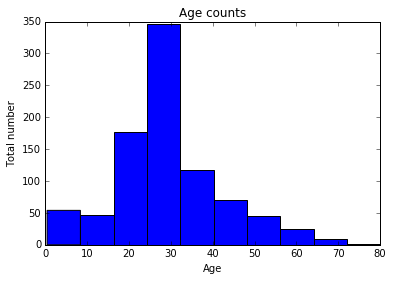

```python
import matplotlib.pyplot as plt

plt.hist(age_with_mean, 10)

plt.xlabel("Age")
plt.ylabel("Total number")
plt.title("Age counts")

plt.show()
```

## Stacked bars

What I'd like to now see are the ages on the x-axis and a "stacked bar" on y-axis. A stacked-bar gives you 2 or more pieces of information in *one bar* by dividing the bar on percentages. Might be easiest to show you.

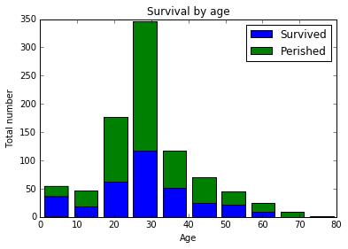

```python
ages_survived = [float(row['Age']) if row['Age'] != '' else 29.7 for row in titanic_table if row['Survived'] == '1']
ages_perished = [float(row['Age']) if row['Age'] != '' else 29.7 for row in titanic_table if row['Survived'] == '0']

plt.hist([ages_survived,ages_perished], 10, stacked=True, label=['Survived','Perished'])

plt.xlabel("Age")
plt.ylabel("Total number")
plt.title("Survival by age")

plt.legend()  # this is new - it uses the label values from the list above

plt.show()
```

Summarizing the code above, I pull out all the ages of passengers that survived then do the same for those who perished. At this point I have 2 lists of ages. I am using an ifelse mapping to avoid building a separate table. Here is how you can do it with a separate table if it makes more sense:

```
survived_table = [row for row in titanic_table if row['Survived'] == '1']
ages_survived = [float(row['Age']) if row['Age'] != '' else 29.69 for row in survived_table]

# ditto for perished
```

Actually, we might find a table of just survivors and a table of just those who did not survive useful in the future so no harm in using a version like above.

Again, we could clean the plot up by centering the age values on the bins and changing the colors of the bars, but I am going to go with what we have.

## Kind of useful

The plot above gives me useful information. It tells me what ages might be good candidates for prediction. For instance, the range 0-10 has a much larger blue piece (survived) than green (perished). It also tells me, by the total length of the bars, there are not than many passengers 10 and under. I'll keep that in mind as we move into building a predictor.

When can you use a stacked plot like this for your own data? You need a numerical range of values for the x-axis. And you need a column with two or more distinct values. You can stack all those values by including them in the list which is the first argument to `hist`. I only had a list of 2. But you could have a list of 3 or 4 if you have a column with 3 or 4 distinct values, e.g., Pclass. Let's look at the Pclass example to hammer this home.

I'll use Pclass as the x-axis. It has 3 possible values. I'll use the y-axis is usual, as a total count of passengers in a class. And I will break each class bar into survived and perished as with age.

First I'll set up my two lists to be stacked. I do not have to use ifelse-mapping because there are no missing values in the Pclass column. All I have to do is convert the string values to ints.

```python
pclass_survived = [int(row['Pclass']) for row in titanic_table if row['Survived'] == '1']
pclass_perished = [int(row['Pclass']) for row in titanic_table if row['Survived'] == '0']
```

Now it's basically copy-and-paste from the stacked aged plot. Then make a few edits and we are good to go.

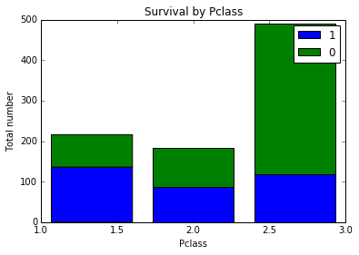

```python
plt.hist([pclass_survived,pclass_perished], 3, stacked=True, label=['1','0'])

plt.xlabel("Pclass")
plt.ylabel("Total number")
plt.title("Survival by Pclass")

plt.legend()  # this is new - it uses the label values from the list above

plt.show()
```

Useful. Tells me that first class bucked the perished trend and had a higher rate of survival than table as whole. Second class also looks like it does better on survival than table as whole. What does this mean for prediction? It means that if someone was in first class, I should predict they survived. Unfortunately, 3rd class has the unhelpful combination of holding most of the rows and being close to overall perished rate. Suggests to me that for those in 3rd class, I am going to have to look at more details (e.g., age) to do better than overall rate.

## Next up

We could certainly do more exploration. We have not touched the columns Parch or Sibsp, nor the Fare and Embarked columns. They may hold powerful predictors. Maybe everyone who embarked in Cherbourg (i.e., 'C') survived. I don't think so but we have not explored it to find out. I think we have enough now to get to prediction so we will go with what we have in the next module.

## Epilog: What plot types did we miss?

Most of them! If you love playing with visuals, there are many features of matplotlib and related Python packages that will let you go crazy. Google around and you can find them. But just as a taste, below is a sampler.

### Incremental complexity

We have been progressing through the plots we are using by starting simple then adding more features. We started with simple `hist`. Then added descriptions of the axis and a title. With stacked bars, we added yet more features. The path you follow to get to different plots will be more of the same. You will have to define new features that are particular to that plot type but reuse other pieces that cut across all plots. The pie chart is a good example. It is slightly more complex in the number of features you have to set up, but should look familiar. Here is the code for a simple pie-chart. Notice that you only have to define the first two variables: the list of labels to go on the pie pieces and the list of sizes of the pie pieces. The reamining code can be used unchanged until you want to explore fancier graphical options.

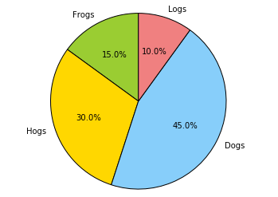

```python
slice_labels = ['Frogs', 'Hogs', 'Dogs', 'Logs']
slice_sizes = [15, 30, 45, 10]
slice_colors = ['yellowgreen', 'gold', 'lightskyblue', 'lightcoral']

plt.pie(slice_sizes,  labels=slice_labels, colors=slice_colors,
        autopct='%1.1f%%', startangle=90)

plt.axis('equal')  # Set aspect ratio to be equal to get a circle.
plt.show()
```

A pie chart with fancier options set:

[figure not shown]

The heat map and GIS style plots below will take some work. The good news is that lots of people get stuck trying to use various plots and they ask questions online. And experts answer! So a combination of going through tutorials and looking at questions on something like stackoverflow.com is a good approach.

[figure not shown]